# Bikeshare-R-project

### Explore Bike Share Data

For this project, your goal is to ask and answer three questions about the available bikeshare data from Washington, Chicago, and New York. This notebook can be submitted directly through the workspace when you are confident in your results.

You will be graded against the project [Rubric](https://review.udacity.com/#!/rubrics/2508/view) by a mentor after you have submitted. To get you started, you can use the template below, but feel free to be creative in your solutions!

```r
ny = read.csv('new_york_city.csv')
wash = read.csv('washington.csv')
chi = read.csv('chicago.csv')
```

```r
head(ny)
tail(ny)
```

| X | Start.Time | End.Time | Trip.Duration | Start.Station | End.Station | User.Type | Gender | Birth.Year |
| --- | --- | --- | --- | --- | --- | --- | --- | --- |
| 5688089 | 2017-06-11 14:55:05 | 2017-06-11 15:08:21 | 795 | Suffolk St & Stanton St | W Broadway & Spring St | Subscriber | Male | 1998 |
| 4096714 | 2017-05-11 15:30:11 | 2017-05-11 15:41:43 | 692 | Lexington Ave & E 63 St | 1 Ave & E 78 St | Subscriber | Male | 1981 |
| 2173887 | 2017-03-29 13:26:26 | 2017-03-29 13:48:31 | 1325 | 1 Pl & Clinton St | Henry St & Degraw St | Subscriber | Male | 1987 |
| 3945638 | 2017-05-08 19:47:18 | 2017-05-08 19:59:01 | 703 | Barrow St & Hudson St | W 20 St & 8 Ave | Subscriber | Female | 1986 |
| 6208972 | 2017-06-21 07:49:16 | 2017-06-21 07:54:46 | 329 | 1 Ave & E 44 St | E 53 St & 3 Ave | Subscriber | Male | 1992 |
| 1285652 | 2017-02-22 18:55:24 | 2017-02-22 19:12:03 | 998 | State St & Smith St | Bond St & Fulton St | Subscriber | Male | 1986 |

|  | X | Start.Time | End.Time | Trip.Duration | Start.Station | End.Station | User.Type | Gender | Birth.Year |
| --- | --- | --- | --- | --- | --- | --- | --- | --- | --- |
| 54765 | 1293888 | 2017-02-23 06:14:14 | 2017-02-23 06:23:32 | 558 | E 27 St & 1 Ave | E 47 St & Park Ave | Subscriber | Male | 1984 |
| 54766 | 642855 | 2017-01-28 16:44:18 | 2017-01-28 16:48:18 | 240 | W 52 St & 9 Ave | 9 Ave & W 45 St | Subscriber | Male | 1991 |
| 54767 | 2157959 | 2017-03-29 06:30:35 | 2017-03-29 06:32:41 | 125 | W 84 St & Columbus Ave | W 87 St & Amsterdam Ave | Subscriber | Male | 1984 |
| 54768 | 5679624 | 2017-06-11 12:52:27 | 2017-06-11 12:58:35 | 367 | 8 Ave & W 33 St | W 45 St & 8 Ave | Subscriber | Male | 1954 |
| 54769 | 6762960 | 2017-06-30 07:48:34 | 2017-06-30 08:17:16 | 1722 | Cathedral Pkwy & Broadway | Broadway & W 51 St | Subscriber | Male | 1974 |
| 54770 | 6078570 | 2017-06-18 16:20:21 | 201 | NA |  |  |  |  | NA |

```r
head(wash)
tail(wash)
```

| X | Start.Time | End.Time | Trip.Duration | Start.Station | End.Station | User.Type |
| --- | --- | --- | --- | --- | --- | --- |
| 1621326 | 2017-06-21 08:36:34 | 2017-06-21 08:44:43 | 489.066 | 14th & Belmont St NW | 15th & K St NW | Subscriber |
| 482740 | 2017-03-11 10:40:00 | 2017-03-11 10:46:00 | 402.549 | Yuma St & Tenley Circle NW | Connecticut Ave & Yuma St NW | Subscriber |
| 1330037 | 2017-05-30 01:02:59 | 2017-05-30 01:13:37 | 637.251 | 17th St & Massachusetts Ave NW | 5th & K St NW | Subscriber |
| 665458 | 2017-04-02 07:48:35 | 2017-04-02 08:19:03 | 1827.341 | Constitution Ave & 2nd St NW/DOL | M St & Pennsylvania Ave NW | Customer |
| 1481135 | 2017-06-10 08:36:28 | 2017-06-10 09:02:17 | 1549.427 | Henry Bacon Dr & Lincoln Memorial Circle NW | Maine Ave & 7th St SW | Subscriber |
| 1148202 | 2017-05-14 07:18:18 | 2017-05-14 07:24:56 | 398.000 | 1st & K St SE | Eastern Market Metro / Pennsylvania Ave & 7th St SE | Subscriber |

|  | X | Start.Time | End.Time | Trip.Duration | Start.Station | End.Station | User.Type |
| --- | --- | --- | --- | --- | --- | --- | --- |
| 89046 | 1484340 | 2017-06-10 10:58:09 | 2017-06-10 11:25:58 | 1669.700 | M St & New Jersey Ave SE | 4th St & Madison Dr NW | Customer |
| 89047 | 555788 | 2017-03-22 18:46:00 | 2017-03-22 19:04:00 | 1082.789 | 8th & H St NW | 21st & I St NW | Subscriber |
| 89048 | 739004 | 2017-04-09 04:00:22 | 2017-04-09 04:09:54 | 571.879 | Eckington Pl & Q St NE | Columbus Circle / Union Station | Subscriber |
| 89049 | 1214907 | 2017-05-19 09:00:53 | 2017-05-19 09:07:38 | 404.152 | 1st & M St NE | 1st & Rhode Island Ave NW | Subscriber |
| 89050 | 1419806 | 2017-06-06 04:27:33 | 2017-06-06 04:49:59 | 1345.911 | 10th & Florida Ave NW | Georgetown Harbor / 30th St NW | Customer |
| 89051 | 132 |  |  | NA |  |  |  |

```r
head(chi)
tail(chi)
```

| X | Start.Time | End.Time | Trip.Duration | Start.Station | End.Station | User.Type | Gender | Birth.Year |
| --- | --- | --- | --- | --- | --- | --- | --- | --- |
| 1423854 | 2017-06-23 15:09:32 | 2017-06-23 15:14:53 | 321 | Wood St & Hubbard St | Damen Ave & Chicago Ave | Subscriber | Male | 1992 |
| 955915 | 2017-05-25 18:19:03 | 2017-05-25 18:45:53 | 1610 | Theater on the Lake | Sheffield Ave & Waveland Ave | Subscriber | Female | 1992 |
| 9031 | 2017-01-04 08:27:49 | 2017-01-04 08:34:45 | 416 | May St & Taylor St | Wood St & Taylor St | Subscriber | Male | 1981 |
| 304487 | 2017-03-06 13:49:38 | 2017-03-06 13:55:28 | 350 | Christiana Ave & Lawrence Ave | St. Louis Ave & Balmoral Ave | Subscriber | Male | 1986 |
| 45207 | 2017-01-17 14:53:07 | 2017-01-17 15:02:01 | 534 | Clark St & Randolph St | Desplaines St & Jackson Blvd | Subscriber | Male | 1975 |
| 1473887 | 2017-06-26 09:01:20 | 2017-06-26 09:11:06 | 586 | Clinton St & Washington Blvd | Canal St & Taylor St | Subscriber | Male | 1990 |

|  | X | Start.Time | End.Time | Trip.Duration | Start.Station | End.Station | User.Type | Gender | Birth.Year |
| --- | --- | --- | --- | --- | --- | --- | --- | --- | --- |
| 8625 | 397518 | 2017-03-24 16:52:16 | 2017-03-24 16:57:57 | 341 | Southport Ave & Waveland Ave | Southport Ave & Waveland Ave | Subscriber | Male | 1990 |
| 8626 | 879494 | 2017-05-18 05:06:50 | 2017-05-18 05:22:10 | 920 | Artesian Ave & Hubbard St | Wacker Dr & Washington St | Subscriber | Male | 1959 |
| 8627 | 360389 | 2017-03-19 07:21:29 | 2017-03-19 07:27:18 | 349 | Wabash Ave & Roosevelt Rd | Wells St & Polk St | Subscriber | Male | 1987 |
| 8628 | 858496 | 2017-05-16 17:03:24 | 2017-05-16 17:31:12 | 1668 | Ashland Ave & Harrison St | Wells St & Concord Ln | Subscriber | Male | 1963 |
| 8629 | 777620 | 2017-05-10 08:53:03 | 2017-05-10 08:54:32 | 89 | Western Ave & Leland Ave | Western Ave & Leland Ave | Subscriber | Male | 1977 |
| 8630 | 1230561 | 2017-06-11 14:52:13 | 2017-06-11 15:42:33 | 3020 | Waba |  |  |  | NA |

### Question 1

**What is the most common month of travelling in each city?**

1. 'POSIXct'

2. 'POSIXt'

```
2017-01-01 2017-02-01 2017-03-01 2017-04-01 2017-05-01 2017-06-01
      5745       6364       5820      10661      12180      14000
```

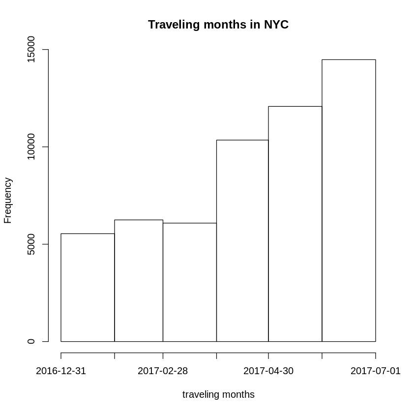

```r
#before performing any action with the variavle Start.Time, it's necessary to make sure whether the class is date\ date-time!
class(ny$Start.Time)

#Altering the class of Start.Time from factor to POSTIXct
ny$Start.Time <- as.POSIXct(ny$Start.Time, " %Y-%m-%d %H:%M:%S")

#I would like to count the items by month # frequencies of travelling by month
tabM_ny<- table(cut(ny$Start.Time, 'month'))
tabM_ny

#plot the frequencies by month using hist-function
hist(ny$Start.Time, "months", xlab = 'traveling months', main = 'Traveling months in NYC', plot = TRUE, freq = TRUE)
```

1. 'POSIXct'

2. 'POSIXt'

```
2017-01-01 2017-02-01 2017-03-01 2017-04-01 2017-05-01 2017-06-01
       650        930        803       1526       1905       2816
```

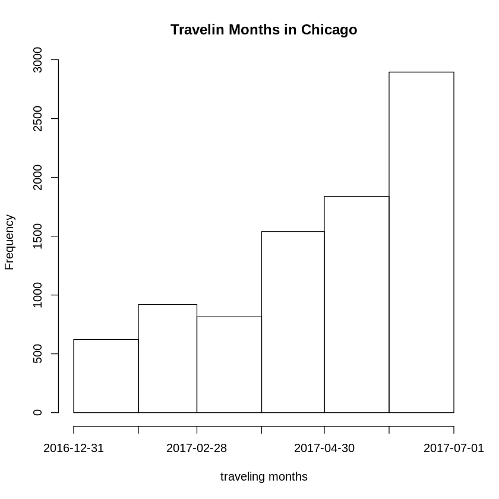

```r
#Altering the class of Start.Time from factor to POSTIXct
chi$Start.Time <- as.POSIXct(chi$Start.Time, " %Y-%m-%d %H:%M:%S")

class(chi$Start.Time) #just to see if the chage has made on the Start.Time from chicago dataset

#frequencies of travelling by month from chicago dataset
tabM_chi<- table(cut(chi$Start.Time, 'month'))
tabM_chi

#plot the frequencies by month using hist-function
hist(chi$Start.Time, "months", xlab = 'traveling months', main = 'Travelin Months in Chicago', plot = TRUE, freq = TRUE)
```

1. 'POSIXct'

2. 'POSIXt'

```
2017-01-01 2017-02-01 2017-03-01 2017-04-01 2017-05-01 2017-06-01
      8946      11563      12612      18522      17072      20335
```

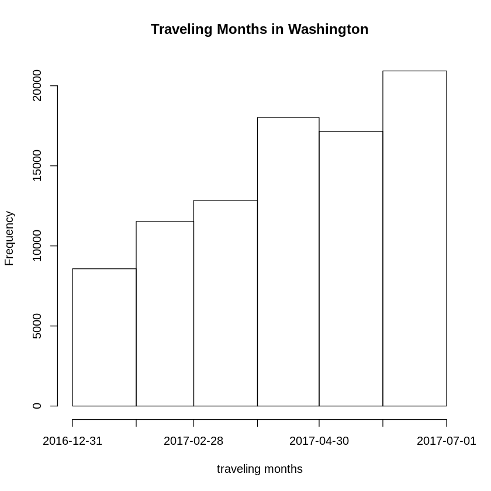

```r
wash$Start.Time <- format(wash$Start.Time, format = "%Y-%m-%d %H:%M:%S") #ajust the format of Start.Time from washiungton dataset

#Altering the class of Start.Time from factor to POSTIXct
wash$Start.Time <- as.POSIXct(wash$Start.Time, format =" %Y-%m-%d %H:%M:%S")
class(wash$Start.Time)

#frequencies of travelling by month from washington dataset
tabM_wash<- table(cut(wash$Start.Time, 'month'))
tabM_wash

#plot the frequencies by month using hist-function
hist(wash$Start.Time, "months", xlab = 'traveling months', main = 'Traveling Months in Washington', plot = TRUE, freq = TRUE)
```

### Question 2

**What is the average travel time for users in each city? is it the accurate measure of central tendacy for this data?**

```
     Min.   1st Qu.    Median      Mean   3rd Qu.      Max.      NA's
     61.0     368.0     610.0     903.6    1051.0 1088634.0         1
```

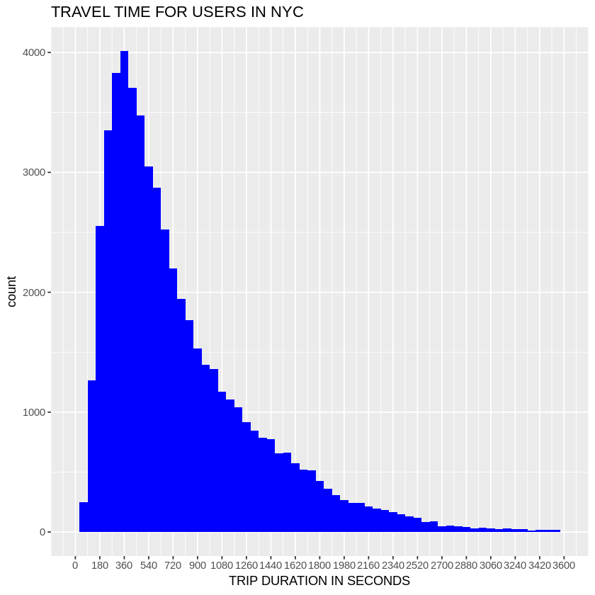

```r
summary(ny$Trip.Duration)  #get basic descriptive statistics using the summary function

ny_mean <-mean(ny$Trip.Duration)  #this does not work if there are NA's

#so, the following code fixes it
ny <- subset(ny, !is.na(Trip.Duration))

#Plot the travel time in NYC
library(ggplot2)

GTD1 <- ggplot(aes(Trip.Duration), data = ny) +
            xlab("TRIP DURATION IN SECONDS") +
        ggtitle("TRAVEL TIME FOR USERS IN NYC") +
        scale_x_continuous(limits = c(0,3600), breaks = seq(0,3600,180) ) +
       geom_histogram(fill = 'blue', binwidth = 60)
GTD1
```

```
   Min. 1st Qu.  Median    Mean 3rd Qu.    Max.
   60.0   394.2   670.0   937.2  1119.0 85408.0
```

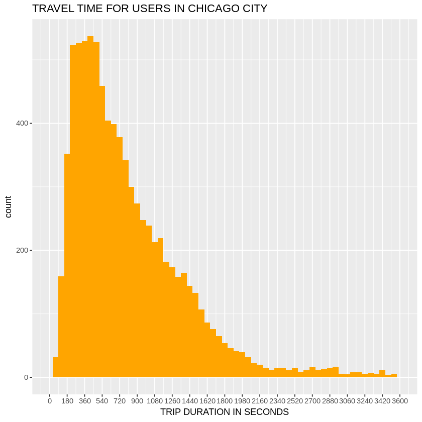

```r
# As we did with NYC data, we do the same with the data set from Chicago city:
summary(chi$Trip.Duration)  #get basic descriptive statistics using the summary function

chi_mean <-mean(chi$Trip.Duration)  #this does work because there're no NA's

#Plot the travel time in Chicago
library(ggplot2)

GTD2 <- ggplot(aes(Trip.Duration), data = chi) +
            xlab("TRIP DURATION IN SECONDS") +
        ggtitle("TRAVEL TIME FOR USERS IN CHICAGO CITY") +
        scale_x_continuous(limits = c(0,3600), breaks = seq(0,3600,180) ) +
       geom_histogram(fill = 'orange', binwidth = 60)
GTD2
```

```
    Min.  1st Qu.   Median     Mean  3rd Qu.     Max.     NA's
    60.3    410.9    707.0   1234.0   1233.2 904591.4        1
```

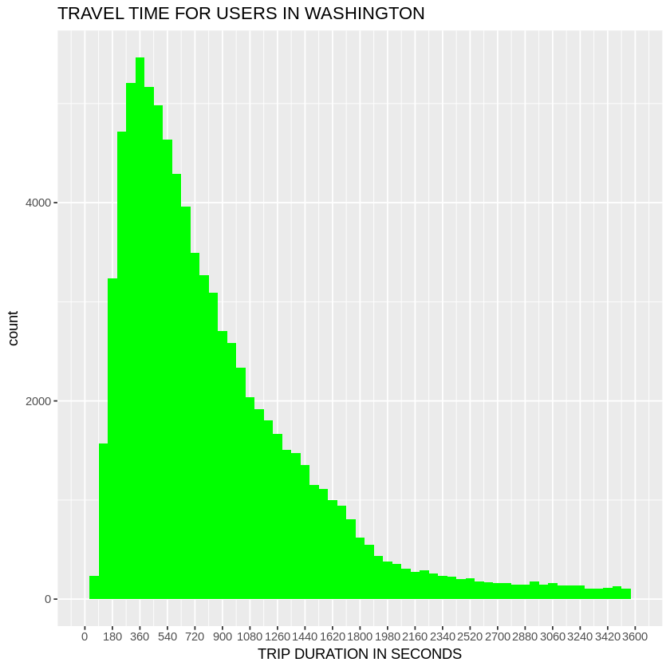

```r
#Same for Washington city:
summary(wash$Trip.Duration)  #get basic descriptive statistics using the summary function

wash_mean <-mean(wash$Trip.Duration)  #this does not work because there's an NA

#so, the following code fixes it
wash <- subset(wash, !is.na(Trip.Duration))

#Plot the travel time in Washington
library(ggplot2)

GTD3 <- ggplot(aes(Trip.Duration), data = wash) +
            xlab("TRIP DURATION IN SECONDS") +
        ggtitle("TRAVEL TIME FOR USERS IN WASHINGTON") +
        scale_x_continuous(limits = c(0,3600), breaks = seq(0,3600,180) ) +
       geom_histogram(fill = 'green', binwidth = 60)
GTD3
```

**The average travel time for all users in NYC is 903 second. 937 second for users in Chicago, and the averge travel time in seconds for users from Washington is 1234.** **Accordding to the trip duration plot for all cities, we can see that the data is squished on the left of the graph, then the graph extends all the way to 3600 seconds. in this case we would prefer to use the Median instead of the mean as a better centeral tendacy measure.** **From the trip duration summaries, the Median for NYC, Chicago, Washington is (resp): 610 s, 670 s, 707 s.**

### Question 3

**What is the total travel time for users in different cities?.**

```r
#calculate the total of trip duration for the three cities
total <- function(x){
    sum <- sum(x)
    return(sum)
         }
```

```r
total(ny$Trip.Duration) #from the total function we creat we can get the total travel time in seconds for NYC
```

49490073

```r
total(chi$Trip.Duration) #TOTAL TRAVEL TIME IN SECONDS FOR CHICAGO CITY
```

8087801

```r
total(wash$Trip.Duration) #TOTAL TRAVEL TIME IN SECONDS FRO WASHINGTON CITY
```

109883544.668

```r
library(lubridate) #load the package lubdidate to so we can convert seconds onto period

ny <- seconds_to_period(total(ny$Trip.Duration)) #it's better to call the variable, to avoid errors if any chages were made

chi <- seconds_to_period(total(chi$Trip.Duration))

wash <- seconds_to_period(total(wash$Trip.Duration))

#orgnise results into table
table <- data.frame(city = c("NYC", "Chicago", "Washington"),
                    total_travel_time=  c(ny,chi, wash)
                   )
table
```

| city | total_travel_time |
| --- | --- |
| NYC | 572d 19H 14M 33S |
| Chicago | 93d 14H 36M 41S |
| Washington | 1271d 19H 12M 24.667999997735S |

## Finishing Up

> Congratulations! You have reached the end of the Explore Bikeshare Data Project. You should be very proud of all you have accomplished!

> **Tip**: Once you are satisfied with your work here, check over your report to make sure that it is satisfies all the areas of the [rubric](https://review.udacity.com/#!/rubrics/2508/view).

## Directions to Submit

> Before you submit your project, you need to create a .html or .pdf version of this notebook in the workspace here. To do that, run the code cell below. If it worked correctly, you should get a return code of 0, and you should see the generated .html file in the workspace directory (click on the orange Jupyter icon in the upper left).

> Alternatively, you can download this report as .html via the **File** > **Download as** submenu, and then manually upload it into the workspace directory by clicking on the orange Jupyter icon in the upper left, then using the Upload button.

> Once you've done this, you can submit your project by clicking on the "Submit Project" button in the lower right here. This will create and submit a zip file with this .ipynb doc and the .html or .pdf version you created. Congratulations!

```r
system('python -m nbconvert Explore_bikeshare_data.ipynb')
```